# An Optimisation Framework for the Well-Conditioning Training of PINNs

Achieving unprecedented accuracy and speed for PINN solutions

[arXiv:2607.02194](https://arxiv.org/pdf/2607.02194)

Joseph Webb

webb@maths.ox.ac.uk

University of Oxford

Sadok Jerad

sadok.jerad@maths.ox.ac.uk

University of Oxford

Coralia Cartis

coralia.cartis@maths.ox.ac.uk

University of Oxford

## Introduction

Classical PDE solvers are extraordinarily effective, but many frontier problems remain difficult: high-dimensional systems, irregular geometries, inverse problems, multi-scale dynamics, and coupling sensor data.

PINNs offer a route beyond these limits, but have a severe accuracy problem.

PINN optimisation problem: a solution $u$ with **zero residuals exists**, and the **PDE residual data is perfect**. However, especially **ill-conditioned** and **non-convex**.

We present an optimisation framework designed for PINNs:

- Priortising internal operations to have utmost numerical accuracy.
- Able locate where conditioning is best – otherwise the perfect data cannot be utilised.
- Leverages the least-squares form and that we enter the small-residual regime.
- Able to overcome the existing $10^{-5}$ and $10^{-8}$ $\ell_2^{\text{rel}}$ barriers observed in single- and double-precision, pushing them to machine precision $\sim 10^{-7}$ and $\sim 10^{-16}$.

## Single-precision fast solve

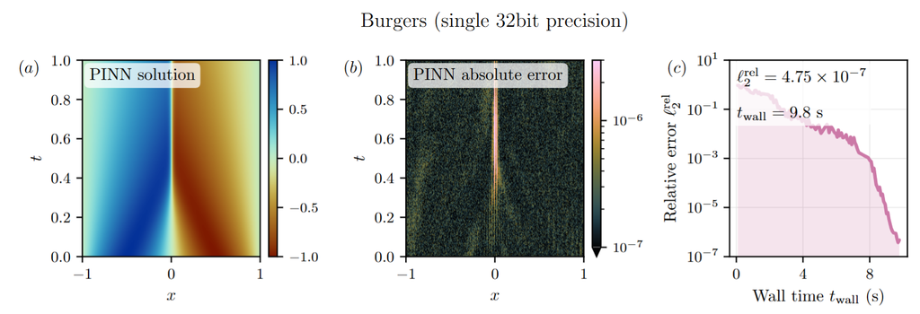

## Double-precision high accuracy solve

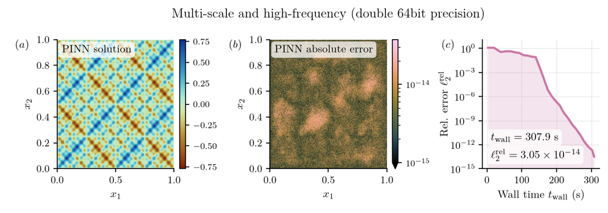

## Notation — PINN

A **PINN** approximates the exact solution $\boldsymbol{u}$ of a PDE problem with a neural network $\boldsymbol{u}_{\boldsymbol{\theta}}$, where $\boldsymbol{\theta} \in \mathbb{R}^{d_{\boldsymbol{\theta}}}$ are trainable parameters.

Definition of a PDE problem (with generally non-linear operators):
$$\begin{aligned}
\boldsymbol{\mathcal{P}}\boldsymbol{u} &= \boldsymbol{0}, && (\boldsymbol{x}, t) \in \Omega \times (0, T], \\
\boldsymbol{\mathcal{I}}\boldsymbol{u} &= \boldsymbol{0}, && (\boldsymbol{x}, t) \in \Omega \times \{0\}, \\
\boldsymbol{\mathcal{B}}\boldsymbol{u} &= \boldsymbol{0}, && (\boldsymbol{x}, t) \in \partial\Omega \times (0, T].
\end{aligned}$$

We adopt the following shorthand, using $\boldsymbol{\mathcal{F}}$, and refer to each element of $\boldsymbol{\mathcal{F}}$ as a *condition*.
$$\boldsymbol{\mathcal{F}}\boldsymbol{u} = \begin{pmatrix} \boldsymbol{\mathcal{P}}\boldsymbol{u} \\ \boldsymbol{\mathcal{I}}\boldsymbol{u} \\ \boldsymbol{\mathcal{B}}\boldsymbol{u} \end{pmatrix} = \boldsymbol{0}.$$

## Notation — Example

A wave problem on $\Omega = (0,1)$ up to $T=1$:

$$\begin{align*}
\boldsymbol{\mathcal{P}}u = &\ u_{tt}(x, t) - c^2 u_{xx}(x, t) = 0, \quad && (x, t) \in (0, 1) \times (0, 1] \\
\boldsymbol{\mathcal{I}}_1u = &\ u(x, t) - \sin(\pi x) + \frac{1}{2}\sin(\beta \pi x) = 0, \quad && (x, t) \in (0, 1) \times \{0\} \\[0.5em]
\boldsymbol{\mathcal{I}}_2u = &\ u_t(x, t) = 0, \quad && (x, t) \in (0, 1) \times \{0\} \\[0.5em]
\boldsymbol{\mathcal{B}}u = &\ u(x, t) = 0, \quad && (x, t) \in \{0, 1\} \times (0, 1]
\end{align*}$$
with $c = 2.0$ and $\beta = 4.0$.

This problem has *four* conditions, $\boldsymbol{\mathcal{F}} = (\boldsymbol{\mathcal{P}}, \boldsymbol{\mathcal{I}}_1, \boldsymbol{\mathcal{I}}_2, \boldsymbol{\mathcal{B}})$.

Our goal is to find $\boldsymbol{\theta}$ such that $\boldsymbol{\mathcal{F}}\boldsymbol{u}_{\boldsymbol{\theta}} = \boldsymbol{0}$.

## Notation — Objective

- $\mathcal{X}_m$ — a set of **sample points** for condition $m$ (e.g. for the PDE residual $\boldsymbol{\mathcal{P}}$, uniform on $\Omega \times (0, T]$).
- $\mathcal{F}_m \boldsymbol{u}_{\boldsymbol{\theta}}(\boldsymbol{x}, t)$ — the **residual** at some point in $\mathcal{X}_m$ for condition $m$.
- $w_m$ — a scalar **weight** for condition $m$.

The network is trained by minimising the following objective, summing over $M$ conditions, and $|\mathcal{X}_m|$ residuals for each condition $m$:

$$\mathcal{L}(\boldsymbol{\theta}) = \dfrac{1}{2} \sum_{m=1}^{M} \frac{w_m}{ |\mathcal{X}_m|} \sum_{(\boldsymbol{x},\, t)\, \in\, \mathcal{X}_m} \!\! \left[{\mathcal{F}}_m \boldsymbol{u}_{\boldsymbol{\theta}}(\boldsymbol{x}, t)\right]^2 = \dfrac{1}{2} \lVert \boldsymbol{r}(\boldsymbol{\theta}) \rVert^2.$$

## Optimiser — Models

To minimise an objective $\mathcal{L}(\boldsymbol{\theta})$ at iteration $k$, update the parameters $\boldsymbol{\theta}_k$ with a step $\boldsymbol{p}_k$ by forming an approximate model of:
$$\mathcal{L}(\boldsymbol{\theta}_k + \mathbf{p}) \approx \mathcal{L}(\boldsymbol{\theta}_k) + \mathbf{g}_k^\mathsf{T} \mathbf{p} + \frac{1}{2} \mathbf{p}^\mathsf{T} \mathbf{H}_k \mathbf{p} + \frac{1}{6} \boldsymbol{\mathcal{T}}_k \mathbf{p}^3 + \dots$$
A quadratic surrogate model has the form:
$$\Phi(\mathbf{p}) = \mathcal{L}(\boldsymbol{\theta}_k) + \mathbf{g}_k^\mathsf{T} \mathbf{p} + \frac{1}{2} \mathbf{p}^\mathsf{T} {\tilde{\mathbf{H}}_k} \mathbf{p}$$

Newton’s method uses the exact $\mathbf{H}_k$:
$$\Phi_{\text{Newton}}(\mathbf{p}) = \mathcal{L}(\boldsymbol{\theta}_k) + \mathbf{g}_k^\mathsf{T} \mathbf{p} + \frac{1}{2} \mathbf{p}^\mathsf{T} \mathbf{H}_k \mathbf{p}$$

We can also perform searches on parameterised models, i.e. on gradient descent:
$$\Phi_{\text{GD}}(\mathbf{p}; \alpha) = \mathcal{L}(\boldsymbol{\theta}_k) + \mathbf{g}_k^\mathsf{T} \mathbf{p} + \frac{1}{2\alpha} \mathbf{p}^\mathsf{T}\mathbf{p}$$

## Optimiser — Gauss–Newton

The Gauss–Newton model:
$$\Phi_{\text{GN}}(\mathbf{p}) = \mathcal{L}(\boldsymbol{\theta}_k) + \left(\mathbf{J}_k^\mathsf{T} \boldsymbol{r}(\boldsymbol{\theta}_k)\right)^\mathsf{T} \mathbf{p} + \frac{1}{2} \mathbf{p}^\mathsf{T} \left(\mathbf{J}_k^\mathsf{T} \mathbf{J}_k\right) \mathbf{p}$$
is for least-squares problems and leverages the Jacobian $\mathbf{J}_k = \nabla_{\boldsymbol{\theta}} \boldsymbol{r}(\boldsymbol{\theta}_k)$ to approximate Newton’s method:

- $\mathbf{g}_k = \nabla \mathcal{L}(\boldsymbol{\theta}_k) = \mathbf{J}_k^\mathsf{T} \boldsymbol{r}(\boldsymbol{\theta}_k)$ is kept precise
- $\mathbf{H}_k = \nabla^2 \mathcal{L}(\boldsymbol{\theta}_k) = \mathbf{J}_k^\mathsf{T} \mathbf{J}_k + \sum_{i} r_i(\boldsymbol{\theta}_k) \nabla^2 r_i(\boldsymbol{\theta}_k) \class{highlight2}{\approx} \mathbf{J}_k^\mathsf{T} \mathbf{J}_k$

The dropped term in the approximation disappears for small residuals.

A quadratic rate of convergence sufficiently close to the solution.

## Optimiser — Levenberg–Marquardt

Gauss–Newton is not parameterised, and can fail to provide progress.

A popular parameterised variation is Levenberg–Marquardt, obtained by adding an $L_2$ norm (Tikhonov) regularisation penalty, with $\lambda \ge 0$:
$$\Phi_{\text{LM}}(\mathbf{p}; \lambda) = \underbrace{\frac{1}{2} \Vert{}\mathbf{r}(\boldsymbol{\theta}_k) + \mathbf{J}_k \mathbf{p}\Vert{}^2}_{\Phi_{\text{GN}}(\mathbf{p})} + \underbrace{\frac{\lambda}{2} \Vert{}\mathbf{p}\Vert{}^2}_{\text{Regularisation}}$$

Equivalently,
$$\Phi_{\text{LM}}(\mathbf{p}; \lambda) = \mathcal{L}(\boldsymbol{\theta}_k) + \left(\mathbf{J}_k^\mathsf{T} \boldsymbol{r}(\boldsymbol{\theta}_k)\right)^\mathsf{T} \mathbf{p} + \frac{1}{2} \mathbf{p}^\mathsf{T} \left(\mathbf{J}_k^\mathsf{T} \mathbf{J}_k + \lambda \mathbf{I}\right) \mathbf{p}$$
which highlights its behaviour at limits
$$\lim_{\lambda \to 0} \Phi_{\text{LM}}(\mathbf{p}; \lambda) = \Phi_{\text{GN}}(\mathbf{p}), \qquad \lim_{\lambda \to \infty} \Phi_{\text{LM}}(\mathbf{p}; \lambda) = \Phi_{\text{GD}}\left(\mathbf{p}; \frac{1}{\lambda}\right)$$

## Example Levenberg–Marquardt steps

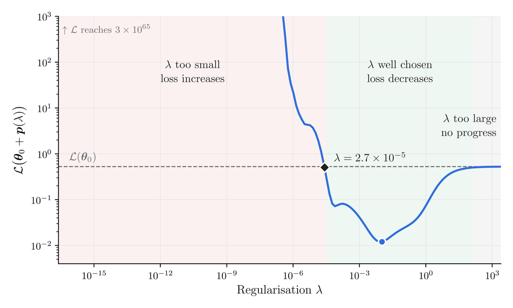

## Regularisation — A necessary evil

The regularisation penalty acts equivalently to appending $d_{\boldsymbol{\theta}}$ zero residuals:

$$\min_{\mathbf{p}}
\frac{1}{2}
\left\Vert
\begin{bmatrix}
\mathbf{r}_k \\
\mathbf{0}
\end{bmatrix}
+
\begin{bmatrix}
\mathbf{J}_k \\
\sqrt{\lambda}\mathbf{I}\,
\end{bmatrix}
\mathbf{p}
\right\Vert^2$$

The optimiser essentially always sees additional observational data.

In an *extremely non-convex* setting, the optimiser can only do as good as the smallest $\lambda$ it saw, as the data was always corrupted at that level or more.

## Impact of regularisation in PINNs

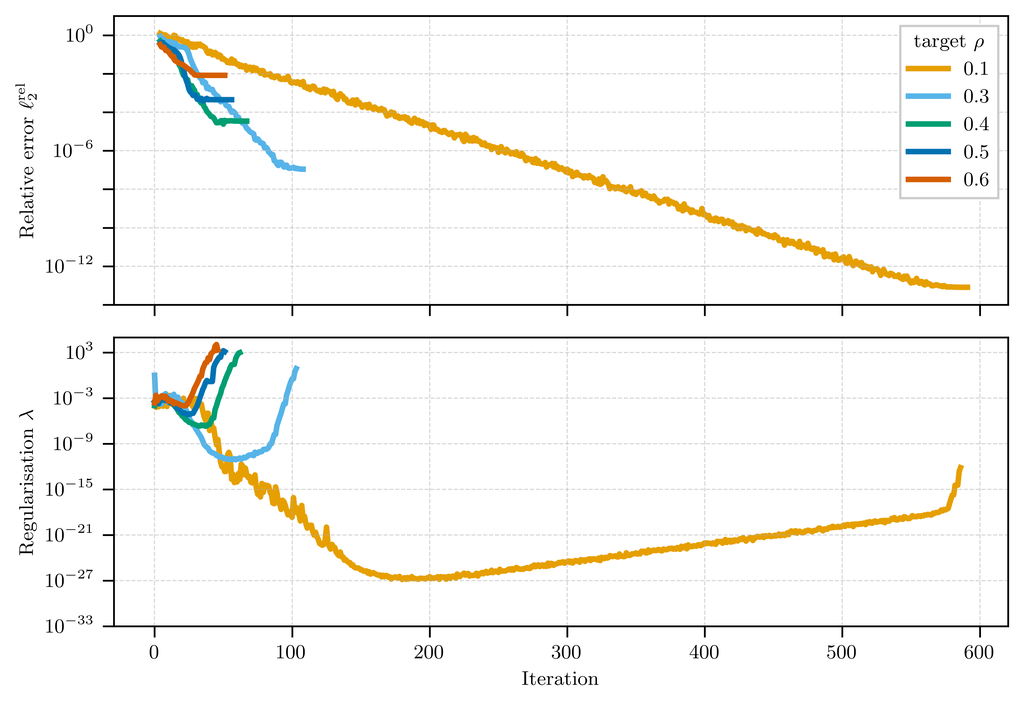

## Visualising the synthetic zero residuals

[interactive chart not shown]

## Levenberg–Marquardt is a trust-region method

The LM step minimises the *regularised* Gauss–Newton model:
$$\mathbf p^{\text{LM}}(\lambda) = \arg\min_{\mathbf p}\; \tfrac12\Vert\mathbf r_k + \mathbf J_k\mathbf p\Vert^2 + \tfrac{\lambda}{2}\Vert\mathbf p\Vert^2
= -\left(\mathbf J_k^\mathsf{T}\mathbf J_k + \lambda\mathbf I\right)^{-1}\mathbf J_k^\mathsf{T}\mathbf r_k.$$

A trust-region method minimises the *unregularised* model inside a ball of radius $\Delta$:
$$\mathbf p^{\text{TR}}(\Delta) = \arg\min_{\mathbf p}\; \tfrac12\Vert\mathbf r_k + \mathbf J_k\mathbf p\Vert^2 \quad \text{subject to} \quad \Vert\mathbf p\Vert \le \Delta.$$

By duality these are the same step: $\lambda$ is the Lagrange multiplier of the constraint, and with $\lambda > 0$ we have $\Delta = \Vert\mathbf p(\lambda)\Vert$.

Choosing $\lambda$ and choosing $\Delta$ are **the same decision**, made in two different coordinates. $\Vert\mathbf p^{\text{LM}}(\lambda)\Vert$ shrinks monotonically as $\lambda$ grows, so every radius $\Delta$ has exactly one $\lambda(\Delta)$.

## Using the SVD

Normal equations

$$\left(\mathbf J^\mathsf{T}\mathbf J + \lambda\mathbf I\right)\mathbf p = -\mathbf J^\mathsf{T}\mathbf r$$

- $\kappa(\mathbf J^\mathsf{T}\mathbf J) = \kappa(\mathbf J)^2 \approx 10^{20}$: beyond double precision
- A new solve (and preconditioner) per $\lambda$

Thin SVD $\;\mathbf J = \mathbf U\boldsymbol\Sigma\mathbf V^\mathsf{T}$, $\;\mathbf g = \mathbf U^\mathsf{T}\mathbf r$

$$\mathbf p^{\text{LM}}(\lambda) = -\mathbf V\operatorname{diag}\!\left(\frac{\sigma_i}{\sigma_i^2+\lambda}\right)\mathbf g$$

- Never forms $\mathbf J^\mathsf{T}\mathbf J$
- One solve, just mulitplication per $\lambda$

One SVD gives the whole family of LM steps and their lengths, cheaply and in parallel.

The SVD also provides the utmost numerical safety and allows for an efficient search over the highly ill-conditioned and non-convex landspace.

## How do we conduct the search?

How do $\lambda$ and $\Delta$ move during an example solve?

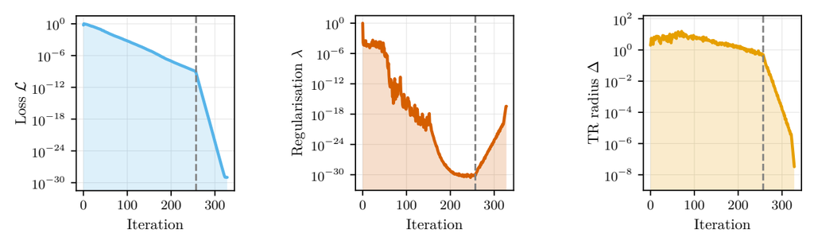

- $\Delta$ is calm: over the first 250 iterations, staying close to $1$.
- $\lambda$ is chaotic: over the same iterations it moves by 30 orders of magnitude.

Trust-region methods keep track of a radius $\Delta_k$ and follow an update rule for subsequent iterations. Our method searches on $q$ geometrically spaced probes around the previous step length:
$$\delta_i = \left(\tfrac{1}{N}\Delta_k\right)^{1-\frac{i-1}{q-1}} \left(N\Delta_k\right)^{\frac{i-1}{q-1}}, \qquad i = 1,\dots,q, \qquad \delta_i \in \left[\tfrac{1}{N}\Delta_k,\; N\Delta_k\right].$$

## From radii to $\lambda$

1. Pick radii $\delta_1,\dots,\delta_q$ around $\Delta_k$.
2. Convert each radius to a $\lambda$ by solving the secular equation with a few Newton iterations, reusing the SVD:
   $$\phi(\lambda) = \sqrt{\sum_j \frac{\sigma_j^2 g_j^2}{(\sigma_j^2+\lambda)^2}} - \delta_i = 0, \qquad \lambda \leftarrow \lambda - \frac{\phi(\lambda)}{\phi'(\lambda)}.$$
   $\phi$ is monotone in $\lambda$, so each solve is a well-posed one-dimensional root-find.
3. Form each step $\mathbf p_i = \mathbf p^{\text{LM}}(\lambda_i)$.

This leaves us with needing some heuristic to select which step we want.

## How to select a step

Consider the ratio $\rho$, which is commonly used in trust-region to judge the quality of a step:
$$\rho = \dfrac{\mathrm{actual\ decrease}}{\mathrm{predicted\ decrease}}$$

Traditional consensus in optimisation theory is that $\rho \approx 0$ means a “poor model”, $\rho \approx 1$ means a “good model”, and typically $\rho > c$ is required for steps to be accepted, often a feature of analysis.

However, a small ratio $\rho$ doesn’t necessarily mean bad progress – its direction may be warning against the local minimum in the hopes of something better.

Both $\lambda$ and $\Delta$ are monotone with $\rho$: an increase in regularisation $\lambda \uparrow$ means a decrease in the step length $\Delta \downarrow$, and an increase in $\rho \uparrow$.

We develop a technique to handle the interplay of $\lambda$, $\Delta$ and $\rho$.

## Selecting from probing cheap candidates

Choose a step with a small target $\rho \approx 0.1$ to promote the decrease of regularisation $\lambda$ and to find a well-conditioned area in parameter space.

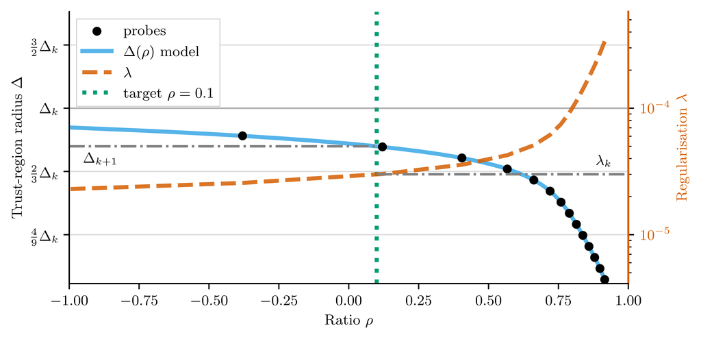

## Implementing a two-stage approach

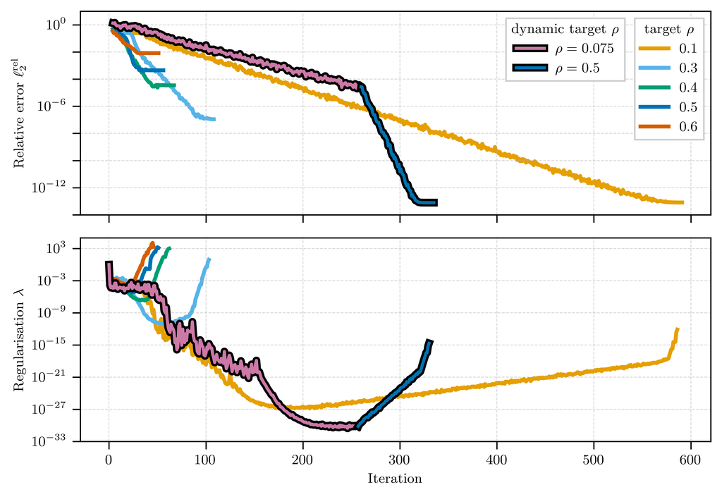

## Efficient Jacobian Computation

PINNs can involve large systems, with lots of residuals and parameters. A Jacobian then involves a lot of derivatives to compute! We need to be able to get it efficiently for what’s proposed so far to work.

[figure not shown]

## Component 1 — Reverse-mode AD in batches

Automatic differentiation has two modes. Given $\boldsymbol{r}: \mathbb{R}^{d_{\boldsymbol\theta}} \to \mathbb{R}^N$:

- Forward mode propagates forwards from a single input — scales as $\mathcal{O}({d_{\boldsymbol\theta}})$.
- Reverse mode propagates backwards from a single output — scales as $\mathcal{O}(N)$.

**Micro-batches**: Apply reverse mode over micro-batches of $b$ residuals.

- Only one $\boldsymbol{J}_\text{micro-batch} \in \mathbb{R}^{b \times d_{\boldsymbol\theta}}$ at a time.
- Scales well and avoides needlessly large computational graphs.

In practise, there’s a tradeoff between function evaluations and the sizes of computational graphs, we choose $b=4$.

**Macro-batches**: To maximise our use of the GPU memory available, we can compute as many $\boldsymbol{J}_\text{micro-batch}$ in parallel as possible.

- Concatenate $\boldsymbol{J}_\text{micro-batch}$ into $\boldsymbol{J}_\text{macro-batch} \in \mathbb{R}^{n\cdot b \times d_{\boldsymbol\theta}}$ per cycle.

## Component 2 — CountSketch

**2004** *Charikar, et al.* “Finding frequent items in data streams”

Rather than forming $\boldsymbol{J} \in \mathbb{R}^{N \times d_{\boldsymbol\theta}}$ explicitly, we instead compute a sketch $\tilde{\boldsymbol{J}} = \boldsymbol{C}\boldsymbol{J} \in \mathbb{R}^{s \times d_{\boldsymbol\theta}}$, where $s \ll N$.

We wish to have linearity, $\boldsymbol{C}\boldsymbol{J} = \sum_\text{batches}\boldsymbol{C}\boldsymbol{J}_\text{macro-batch}$, so that $\boldsymbol{J}$ is never materialised.

> **CountSketch**
> 1. Assign each row $j$ of $\boldsymbol{J}$ a random bucket $h(j) \in \{1,\dots,s\}$ and a random sign $\varepsilon_j \in \{\pm 1\}$.
> 2. Add row $j$ to bucket $h(j)$, multiplied by $\varepsilon_j$.
> 3. Repeat $K$ times to reduce variance.

In PINNs we are free to oversample points aggressively – by using CountSketch, residuals in important regions can naturally dominate their buckets, whilst noise averages away.

## Examples of building Jacobians

We will look at computing Jacobians for various numbers of residuals in the context of Burgers equation with an MLP of 6 layers with width 16. This has $d_{\boldsymbol{\theta}} = 1,431$ parameters.

| N | fwd | rev | fwd ($4$,) | rev ($4$,) | fwd ($4$, $2^{12}$) | rev ($4$, $2^{12}$) | CS + rev ($4$, $2^{12}$) |
| --- | --- | --- | --- | --- | --- | --- | --- |
| $2^{12}$ | 0.019s | 0.101s | 0.021s | 0.001s | 0.021s | 0.001s | 0.001s |
| $2^{14}$ | OOM | OOM | 0.077s | 0.002s | 0.080s | 0.003s | 0.003s |
| $2^{16}$ | OOM | OOM | OOM | 0.006s | 0.320s | 0.010s | 0.011s |
| $2^{18}$ | OOM | OOM | OOM | 0.030s | 1.302s | 0.039s | 0.041s |
| $2^{20}$ | OOM | OOM | OOM | OOM | 5.205s | 0.153s | 0.163s |

Perfomed on a NVIDIA H100 – Out of memory issues can be expected to be much worse on smaller GPUs, which are alleviated with our method. CountSketch uses $s=600$.

## Component 3 — SRCT

**2009** *Halko, et al.* “Finding structure with randomness […]”

> **SRTT (Subsampled Random Trigonometric Transform)**
> 1. A random sign flip $\boldsymbol{D} \in \mathbb{R}^{d_{\boldsymbol\theta}\times d_{\boldsymbol\theta}}$
> 2. A random permutation $\boldsymbol{\Pi} \in \mathbb{R}^{d_{\boldsymbol\theta}\times d_{\boldsymbol\theta}}$
> 3. A unitary trigonometric transform $\boldsymbol{F} \in \mathbb{R}^{d_{\boldsymbol\theta}\times d_{\boldsymbol\theta}}$ (applied as an FFT)
> 4. A random restriction $\boldsymbol{S} \in \mathbb{R}^{d_{\boldsymbol\theta}\times s}$:
>    $$\begin{equation}
>    (\boldsymbol\Omega)\,\boldsymbol{S} = (\boldsymbol{D}\, \boldsymbol{\Pi}\, \boldsymbol{F})\, \boldsymbol{S}.
>    \end{equation}$$

As we deal with real-valued matrices, we opt for the **cosine** variant (SRCT).

This creates a doubly-sketched Jacobian $\tilde{\boldsymbol{J}} \in \mathbb{R}^{s_1 \times s_2}$.

## Examples of building Jacobians

$$\tilde{\boldsymbol{J}} \gets \tilde{\boldsymbol{J}} + \sqrt{2 w_m / |\mathcal{X}_m|}\, \boldsymbol{C}\, \boldsymbol{J}_{\mathrm{batch}} \, \boldsymbol{\Omega}\, \boldsymbol{S}$$

Results for computing $\tilde{\boldsymbol{J}}$ with true $\boldsymbol{J} \in \mathbb{R}^{2^{16} \times d_{\boldsymbol\theta}}$, followed by taking the SVD:

| MLP shape | $d_{\boldsymbol\theta}$ | Sketch size $s$ | CS + SVD | CS + SRCT + SVD |
| --- | --- | --- | --- | --- |
| 16, 16, 16, 16 | 885 | 500 | 0.051s | 0.035s |
| 32, 32, 32, 32 | 3,301 | 1,000 | 0.238s | 0.108s |
| 64, 64, 64, 64 | 12,741 | 5,000 | 3.365s | 1.548s |
| 128, 128, 128, 128 | 50,053 | 10,000 | 18.390s | 7.824s |

## Recap of optimisation framework

- By utilising an interaction between batched reverse-mode automatic differentiation and CountSketch, we can quickly, and efficiently in memory, build sketched Jacobians.
- By sketching in parameter space with a subsampled randomised cosine transform, we can be scalable with large networks, and facilitate fast SVD computations; the isotropic embedding provides a more stable space for trust-region computations.
- Levenberg–Marquardt alongside the SVD provides the most numerically safe way to obtain many high-quality and cheap candidate steps.
- We can create interpolation models $\Delta(\rho)$ and $\lambda(\rho)$. This allows us to take large steps which attain small target values of $\rho$, where the feasible regularisation is smallest.
- All of these together produces incredibly effective steps which take little compute time.

Numerical Results

## Kuramoto–Sivashinsky

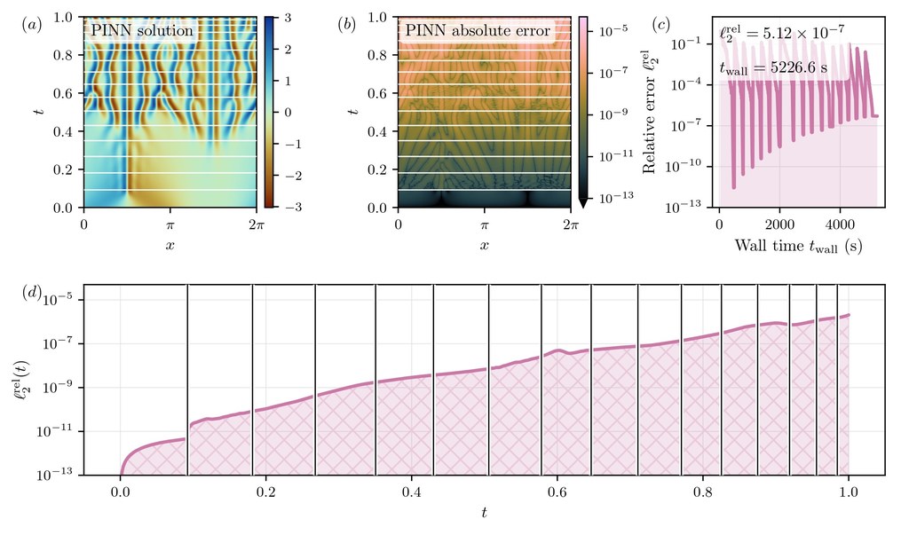

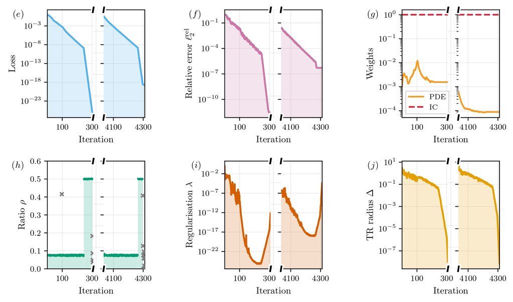

## Navier–Stokes lid-driven cavity

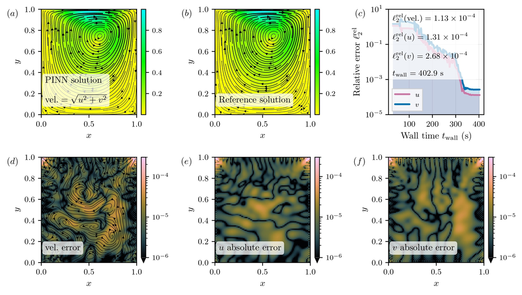

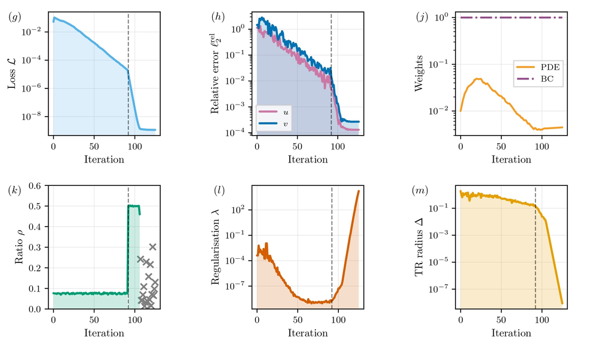

## Wave

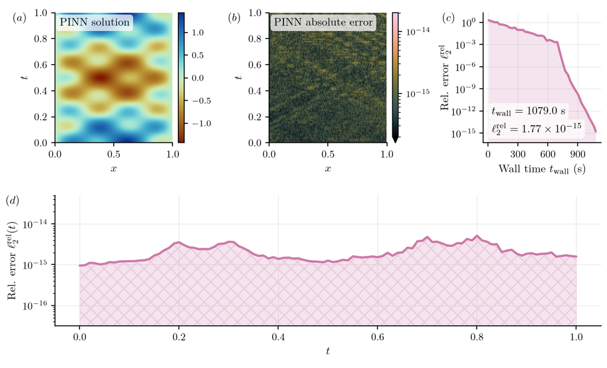

## Korteweg–de Vries

[figure not shown]

## Navier–Stokes DFG 2D-1 benchmark

$x$-velocity field is accurate with $0.00083\%$, when compared to FEM reference.

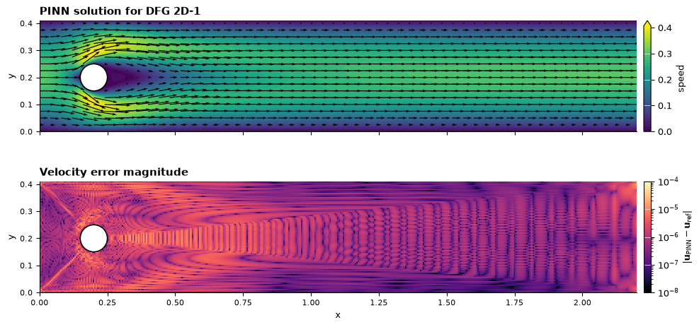

## Results

[output not shown]

## Perspectives

When the optimiser error no longer becomes the bottleneck, and solutions become very accurate, new challenges appear in PINNs.

- **Summation errors**: PDE residuals are $\mathcal{P}[u] = u_t + u u_x + \dots = a_1 + a_2 + \dots = 0$, but machine limits cause errors $\hat a_i = a_i(1+\delta_i)$, and so a perfect solution carries an error $\sum_i \hat a_i = \underbrace{\sum_i a_i}_{=0} + \sum_i a_i \delta_i$. A reformulation of the PDE discouraging large terms can be used.
- **Architectural conditioning**: even trying our best with the SVD, the ill-conditioning still proves a challenge. Neural network choices, such as specific overparameterisation techqniues, can allow for lower regularisations, and hence more accurate solutions, to be achieved.
- *Accurate* solutions can live very far away in parameter space from even close ones.
- The quality of the solution can be decided early based on the conditioning of the region, even very early iterations can give a hint as to whether the solution will be of decent quality. **Can this be leveraged further?**

## Remarks

[figure not shown]

- We show that our optimiser named **DSGNAR** (Doubly-Sketched Gauss–Newton with Adaptive Ratio) presented in the paper [arXiv:2607.02194](https://arxiv.org/pdf/2607.02194), can solve many PINN problems to close to machine precision.
- **DSGNAR** also presents a new type of optimisation, focused on regularisation rather than just the objective. It descends quickly only once it is confident that the true accurate data can be properly utilised.
- The optimisation framework is not dependent on the PDE, the architecture, or approach.
- Scalable, as the sketches are built in parts, which allows the use of an arbitrary number of residual points and network parameters.